# Practical Machine Learning Course Project

Gustavo Jimenez-Maggiora

April 26, 2015

```r
require(caret)
require(mlbench)
# require(party)
require(randomForest)

set.seed(7)
```

## Data

We are using the training and testing sets provided.

```r
training <- read.csv('./pml-training.csv')
testing <- read.csv('./pml-testing.csv')
```

Upon review of the data set, several columns were removed.

First, we removed any columns that had zero or close to zero variance in the training set.

```r
remove <- nearZeroVar(training)
training <- training[,-remove]
testing <- testing[,-remove]
```

Secondly, we removed any columns that have NA values (**NOTE**: we assume that the same columns have NA’s in the testing set).

```r
ok <- apply(training, 2, function(x) !any(is.na(x)))
training <- training[,ok]
testing <- testing[,ok]
```

Finally, we remove any variables that are summary statistics calculated by the authors of the data set (eg. skewness, kurtosis, etc.)

```r
not_ok <- grepl('^(X|cvtd_timestamp|kurtosis|skewness|max_|min_|amplitude)',colnames(training));

training<-training[,!not_ok]
testing<-testing[,!not_ok]
```

The final training data set is the following (**NOTE**: the testing set has the same structure):

```r
# Dimensions
dim(training)
```

```
## [1] 19622    57
```

```r
dim(testing)
```

```
## [1] 20 57
```

```r
# Summary - training data
summary(training)
```

```
##     user_name    raw_timestamp_part_1 raw_timestamp_part_2   num_window
##  adelmo  :3892   Min.   :1.322e+09    Min.   :   294       Min.   :  1.0
##  carlitos:3112   1st Qu.:1.323e+09    1st Qu.:252912       1st Qu.:222.0
##  charles :3536   Median :1.323e+09    Median :496380       Median :424.0
##  eurico  :3070   Mean   :1.323e+09    Mean   :500656       Mean   :430.6
##  jeremy  :3402   3rd Qu.:1.323e+09    3rd Qu.:751891       3rd Qu.:644.0
##  pedro   :2610   Max.   :1.323e+09    Max.   :998801       Max.   :864.0
##    roll_belt        pitch_belt          yaw_belt       total_accel_belt
##  Min.   :-28.90   Min.   :-55.8000   Min.   :-180.00   Min.   : 0.00
##  1st Qu.:  1.10   1st Qu.:  1.7600   1st Qu.: -88.30   1st Qu.: 3.00
##  Median :113.00   Median :  5.2800   Median : -13.00   Median :17.00
##  Mean   : 64.41   Mean   :  0.3053   Mean   : -11.21   Mean   :11.31
##  3rd Qu.:123.00   3rd Qu.: 14.9000   3rd Qu.:  12.90   3rd Qu.:18.00
##  Max.   :162.00   Max.   : 60.3000   Max.   : 179.00   Max.   :29.00
##   gyros_belt_x        gyros_belt_y       gyros_belt_z
##  Min.   :-1.040000   Min.   :-0.64000   Min.   :-1.4600
##  1st Qu.:-0.030000   1st Qu.: 0.00000   1st Qu.:-0.2000
##  Median : 0.030000   Median : 0.02000   Median :-0.1000
##  Mean   :-0.005592   Mean   : 0.03959   Mean   :-0.1305
##  3rd Qu.: 0.110000   3rd Qu.: 0.11000   3rd Qu.:-0.0200
##  Max.   : 2.220000   Max.   : 0.64000   Max.   : 1.6200
##   accel_belt_x       accel_belt_y     accel_belt_z     magnet_belt_x
##  Min.   :-120.000   Min.   :-69.00   Min.   :-275.00   Min.   :-52.0
##  1st Qu.: -21.000   1st Qu.:  3.00   1st Qu.:-162.00   1st Qu.:  9.0
##  Median : -15.000   Median : 35.00   Median :-152.00   Median : 35.0
##  Mean   :  -5.595   Mean   : 30.15   Mean   : -72.59   Mean   : 55.6
##  3rd Qu.:  -5.000   3rd Qu.: 61.00   3rd Qu.:  27.00   3rd Qu.: 59.0
##  Max.   :  85.000   Max.   :164.00   Max.   : 105.00   Max.   :485.0
##  magnet_belt_y   magnet_belt_z       roll_arm         pitch_arm
##  Min.   :354.0   Min.   :-623.0   Min.   :-180.00   Min.   :-88.800
##  1st Qu.:581.0   1st Qu.:-375.0   1st Qu.: -31.77   1st Qu.:-25.900
##  Median :601.0   Median :-320.0   Median :   0.00   Median :  0.000
##  Mean   :593.7   Mean   :-345.5   Mean   :  17.83   Mean   : -4.612
##  3rd Qu.:610.0   3rd Qu.:-306.0   3rd Qu.:  77.30   3rd Qu.: 11.200
##  Max.   :673.0   Max.   : 293.0   Max.   : 180.00   Max.   : 88.500
##     yaw_arm          total_accel_arm  gyros_arm_x        gyros_arm_y
##  Min.   :-180.0000   Min.   : 1.00   Min.   :-6.37000   Min.   :-3.4400
##  1st Qu.: -43.1000   1st Qu.:17.00   1st Qu.:-1.33000   1st Qu.:-0.8000
##  Median :   0.0000   Median :27.00   Median : 0.08000   Median :-0.2400
##  Mean   :  -0.6188   Mean   :25.51   Mean   : 0.04277   Mean   :-0.2571
```

[output cut: 57 more lines]

```
##  Max.   :311.00000   Max.   :231.0000   Max.   : 477.00   Max.   : 923.0
##  accel_forearm_z   magnet_forearm_x  magnet_forearm_y magnet_forearm_z
##  Min.   :-446.00   Min.   :-1280.0   Min.   :-896.0   Min.   :-973.0
##  1st Qu.:-182.00   1st Qu.: -616.0   1st Qu.:   2.0   1st Qu.: 191.0
##  Median : -39.00   Median : -378.0   Median : 591.0   Median : 511.0
##  Mean   : -55.29   Mean   : -312.6   Mean   : 380.1   Mean   : 393.6
##  3rd Qu.:  26.00   3rd Qu.:  -73.0   3rd Qu.: 737.0   3rd Qu.: 653.0
##  Max.   : 291.00   Max.   :  672.0   Max.   :1480.0   Max.   :1090.0
##  classe
##  A:5580
##  B:3797
##  C:3422
##  D:3216
##  E:3607
##
```

## Feature Selection

We use Recursive Feature Elimination (RFE) for automated feature selection with 10-fold cross validation:

```r
# Run RFE
control <- rfeControl(functions=rfFuncs, method="cv", number=10)
fitRFE <- rfe(training[,-57], training[,57], rfeControl = control)
```

Results of RFE feature selection:

```r
fitRFE
```

```
##
## Recursive feature selection
##
## Outer resampling method: Cross-Validated (10 fold)
##
## Resampling performance over subset size:
##
##  Variables Accuracy  Kappa AccuracySD   KappaSD Selected
##          4   0.9999 0.9999  0.0002148 0.0002717        *
##          8   0.9996 0.9995  0.0004194 0.0005305
##         16   0.9995 0.9994  0.0005606 0.0007091
##         56   0.9992 0.9990  0.0009362 0.0011842
##
## The top 4 variables (out of 4):
##    raw_timestamp_part_1, num_window, roll_belt, yaw_belt
```

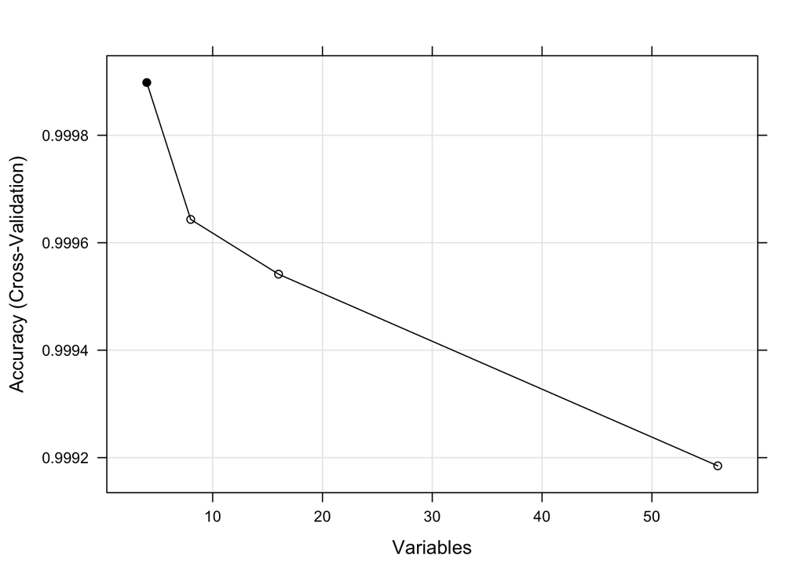

```r
trellis.par.set(caretTheme())
plot(fitRFE, type = c("g", "o"))
```

## Methods

**Recursive Partitioning**

```r
# RPART
fitRP<-train(classe ~ raw_timestamp_part_1 + num_window + roll_belt + yaw_belt, data=training, method='rpart')
```

**Random Forest**

```r
# Random Forest
fitRF<-train(classe ~ raw_timestamp_part_1 + num_window + roll_belt + yaw_belt, data=training, method='rf')
```

To find the best performing method, we compare estimated accuracy and ooe results for various models:

```r
# Compare models using mlbench
results <- resamples(list(RP=fitRP, RF=fitRF))
summary(results)
```

```
##
## Call:
## summary.resamples(object = results)
##
## Models: RP, RF
## Number of resamples: 25
##
## Accuracy
##      Min. 1st Qu. Median   Mean 3rd Qu.   Max. NA's
## RP 0.3577  0.4366 0.5030 0.4757  0.5278 0.5665    0
## RF 0.9990  0.9997 0.9997 0.9997  0.9999 1.0000    0
##
## Kappa
##      Min. 1st Qu. Median   Mean 3rd Qu.   Max. NA's
## RP 0.1194  0.2656 0.3485 0.3040  0.3836 0.4389    0
## RF 0.9988  0.9996 0.9997 0.9997  0.9998 1.0000    0
```

Based on this comparison, we select the **Random Forest** model:

```r
fitRF
```

[output not shown]

```r
fitRF$finalModel
```

```
##
## Call:
##  randomForest(x = x, y = y, mtry = param$mtry)
##                Type of random forest: classification
##                      Number of trees: 500
## No. of variables tried at each split: 2
##
##         OOB estimate of  error rate: 0.01%
## Confusion matrix:
##      A    B    C    D    E  class.error
## A 5580    0    0    0    0 0.0000000000
## B    1 3796    0    0    0 0.0002633658
## C    0    0 3422    0    0 0.0000000000
## D    0    0    0 3216    0 0.0000000000
## E    0    0    0    1 3606 0.0002772387
```

## Predictive Model

We perform prediction on the testing set using the model we have selected.

```r
pRF <- predict(fitRF, testing)
pRF
```

```
##  [1] B A B A A E D B A A B C B A E E A B B B
## Levels: A B C D E
```

**Predicted Outcomes**

```r
# Function to write predicted results
pml_write_files = function(x){
  n = length(x)
  for(i in 1:n){
    filename = paste0("problem_id_",i,".txt")
    write.table(x[i],file=filename,quote=FALSE,row.names=FALSE,col.names=FALSE)
  }
}
```

```r
final_results <- data.frame(pred = pRF)
final_results
```

```
##    pred
## 1     B
## 2     A
## 3     B
## 4     A
## 5     A
## 6     E
## 7     D
## 8     B
## 9     A
## 10    A
## 11    B
## 12    C
## 13    B
## 14    A
## 15    E
## 16    E
## 17    A
## 18    B
## 19    B
## 20    B
```

```r
pml_write_files(pRF)
```

## Conclusion

In conclusion, we found optimal subset of predictors using RFE consisting of four predictors: raw_timestamp_part_1, num_window, roll_belt, and yaw_belt. A RF model was developed using this subset with an OOB error rate of **0.01%**.